# CardChurnWorking

Mrunal

04/06/2022

Reading the File

```r
filePath<-"C:/Users/mruna/Documents/Dataset_BankChurners.csv"
ChurnDataV1<-read.csv(filePath, header=T, stringsAsFactors=F, na.strings=c("", "NA"))
```

Overview of Dataset

```r
str(ChurnDataV1)
```

```
## 'data.frame':    10127 obs. of  20 variables:
##  $ Attrition_Flag          : chr  "Existing Customer" "Existing Customer" "Existing Customer" "Existing Customer" ...
##  $ Customer_Age            : int  45 49 51 40 40 44 51 32 37 48 ...
##  $ Gender                  : chr  "M" "F" "M" "F" ...
##  $ Dependent_count         : int  3 5 3 4 3 2 4 0 3 2 ...
##  $ Education_Level         : chr  "High School" "Graduate" "Graduate" "High School" ...
##  $ Marital_Status          : chr  "Married" "Single" "Married" "Unknown" ...
##  $ Income_Category         : chr  "$60K - $80K" "Less than $40K" "$80K - $120K" "Less than $40K" ...
##  $ Card_Category           : chr  "Blue" "Blue" "Blue" "Blue" ...
##  $ Months_on_book          : int  39 44 36 34 21 36 46 27 36 36 ...
##  $ Total_Relationship_Count: int  5 6 4 3 5 3 6 2 5 6 ...
##  $ Months_Inactive_12_mon  : int  1 1 1 4 1 1 1 2 2 3 ...
##  $ Contacts_Count_12_mon   : int  3 2 0 1 0 2 3 2 0 3 ...
##  $ Credit_Limit            : num  12691 8256 3418 3313 4716 ...
##  $ Total_Revolving_Bal     : int  777 864 0 2517 0 1247 2264 1396 2517 1677 ...
##  $ Avg_Open_To_Buy         : num  11914 7392 3418 796 4716 ...
##  $ Total_Amt_Chng_Q4_Q1    : num  1.33 1.54 2.59 1.4 2.17 ...
##  $ Total_Trans_Amt         : int  1144 1291 1887 1171 816 1088 1330 1538 1350 1441 ...
##  $ Total_Trans_Ct          : int  42 33 20 20 28 24 31 36 24 32 ...
##  $ Total_Ct_Chng_Q4_Q1     : num  1.62 3.71 2.33 2.33 2.5 ...
##  $ Avg_Utilization_Ratio   : num  0.061 0.105 0 0.76 0 0.311 0.066 0.048 0.113 0.144 ...
```

Converting to Factors

```r
ChurnDataV1$Attrition_Flag<-factor(ChurnDataV1$Attrition_Flag, labels=c("Attrited", "Existing"))
ChurnDataV1$Gender<-factor(ChurnDataV1$Gender, labels=c("Female", "Male"))
ChurnDataV1$Education_Level<-factor(ChurnDataV1$Education_Level, labels=c("College", "Doctorate", "Graduate", "High School", "Post Graduate", "Uneducated", "Unknown"))
ChurnDataV1$Marital_Status<-factor(ChurnDataV1$Marital_Status, labels=c("Divorced", "Married", "Single", "Unknown"))
ChurnDataV1$Income_Category<-factor(ChurnDataV1$Income_Category, labels=c("$120K+", "$40K-$60K", "$60K-$80K", "$80K-$120K", "Less than $40K", "Unknown"))
ChurnDataV1$Card_Category<-factor(ChurnDataV1$Card_Category, labels=c("Blue", "Gold", "Platinum", "Silver"))
```

Overview of Dataset

```r
str(ChurnDataV1)
```

```
## 'data.frame':    10127 obs. of  20 variables:
##  $ Attrition_Flag          : Factor w/ 2 levels "Attrited","Existing": 2 2 2 2 2 2 2 2 2 2 ...
##  $ Customer_Age            : int  45 49 51 40 40 44 51 32 37 48 ...
##  $ Gender                  : Factor w/ 2 levels "Female","Male": 2 1 2 1 2 2 2 2 2 2 ...
##  $ Dependent_count         : int  3 5 3 4 3 2 4 0 3 2 ...
##  $ Education_Level         : Factor w/ 7 levels "College","Doctorate",..: 4 3 3 4 6 3 7 4 6 3 ...
##  $ Marital_Status          : Factor w/ 4 levels "Divorced","Married",..: 2 3 2 4 2 2 2 4 3 3 ...
##  $ Income_Category         : Factor w/ 6 levels "$120K+","$40K-$60K",..: 3 5 4 5 3 2 1 3 3 4 ...
##  $ Card_Category           : Factor w/ 4 levels "Blue","Gold",..: 1 1 1 1 1 1 2 4 1 1 ...
##  $ Months_on_book          : int  39 44 36 34 21 36 46 27 36 36 ...
##  $ Total_Relationship_Count: int  5 6 4 3 5 3 6 2 5 6 ...
##  $ Months_Inactive_12_mon  : int  1 1 1 4 1 1 1 2 2 3 ...
##  $ Contacts_Count_12_mon   : int  3 2 0 1 0 2 3 2 0 3 ...
##  $ Credit_Limit            : num  12691 8256 3418 3313 4716 ...
##  $ Total_Revolving_Bal     : int  777 864 0 2517 0 1247 2264 1396 2517 1677 ...
##  $ Avg_Open_To_Buy         : num  11914 7392 3418 796 4716 ...
##  $ Total_Amt_Chng_Q4_Q1    : num  1.33 1.54 2.59 1.4 2.17 ...
##  $ Total_Trans_Amt         : int  1144 1291 1887 1171 816 1088 1330 1538 1350 1441 ...
##  $ Total_Trans_Ct          : int  42 33 20 20 28 24 31 36 24 32 ...
##  $ Total_Ct_Chng_Q4_Q1     : num  1.62 3.71 2.33 2.33 2.5 ...
##  $ Avg_Utilization_Ratio   : num  0.061 0.105 0 0.76 0 0.311 0.066 0.048 0.113 0.144 ...
```

```r
summary(ChurnDataV1)
```

```
##   Attrition_Flag  Customer_Age      Gender     Dependent_count
##  Attrited:1627   Min.   :26.00   Female:5358   Min.   :0.000
##  Existing:8500   1st Qu.:41.00   Male  :4769   1st Qu.:1.000
##                  Median :46.00                 Median :2.000
##                  Mean   :46.33                 Mean   :2.346
##                  3rd Qu.:52.00                 3rd Qu.:3.000
##                  Max.   :73.00                 Max.   :5.000
##
##       Education_Level  Marital_Status       Income_Category  Card_Category
##  College      :1013   Divorced: 748   $120K+        : 727   Blue    :9436
##  Doctorate    : 451   Married :4687   $40K-$60K     :1790   Gold    : 116
##  Graduate     :3128   Single  :3943   $60K-$80K     :1402   Platinum:  20
##  High School  :2013   Unknown : 749   $80K-$120K    :1535   Silver  : 555
##  Post Graduate: 516                   Less than $40K:3561
##  Uneducated   :1487                   Unknown       :1112
##  Unknown      :1519
##  Months_on_book  Total_Relationship_Count Months_Inactive_12_mon
##  Min.   :13.00   Min.   :1.000            Min.   :0.000
##  1st Qu.:31.00   1st Qu.:3.000            1st Qu.:2.000
##  Median :36.00   Median :4.000            Median :2.000
##  Mean   :35.93   Mean   :3.813            Mean   :2.341
##  3rd Qu.:40.00   3rd Qu.:5.000            3rd Qu.:3.000
##  Max.   :56.00   Max.   :6.000            Max.   :6.000
##
##  Contacts_Count_12_mon  Credit_Limit   Total_Revolving_Bal Avg_Open_To_Buy
##  Min.   :0.000         Min.   : 1438   Min.   :   0        Min.   :    3
##  1st Qu.:2.000         1st Qu.: 2555   1st Qu.: 359        1st Qu.: 1324
##  Median :2.000         Median : 4549   Median :1276        Median : 3474
##  Mean   :2.455         Mean   : 8632   Mean   :1163        Mean   : 7469
##  3rd Qu.:3.000         3rd Qu.:11068   3rd Qu.:1784        3rd Qu.: 9859
##  Max.   :6.000         Max.   :34516   Max.   :2517        Max.   :34516
##
##  Total_Amt_Chng_Q4_Q1 Total_Trans_Amt Total_Trans_Ct   Total_Ct_Chng_Q4_Q1
##  Min.   :0.0000       Min.   :  510   Min.   : 10.00   Min.   :0.0000
##  1st Qu.:0.6310       1st Qu.: 2156   1st Qu.: 45.00   1st Qu.:0.5820
##  Median :0.7360       Median : 3899   Median : 67.00   Median :0.7020
##  Mean   :0.7599       Mean   : 4404   Mean   : 64.86   Mean   :0.7122
##  3rd Qu.:0.8590       3rd Qu.: 4741   3rd Qu.: 81.00   3rd Qu.:0.8180
##  Max.   :3.3970       Max.   :18484   Max.   :139.00   Max.   :3.7140
##
##  Avg_Utilization_Ratio
##  Min.   :0.0000
##  1st Qu.:0.0230
##  Median :0.1760
##  Mean   :0.2749
##  3rd Qu.:0.5030
##  Max.   :0.9990
##
```

Standard Deviation

```r
ChurnDataNum<-ChurnDataV1[c(2,4,9,10,11,12,13,14,15,16,17,18,19,20)]
apply(ChurnDataNum, 2, sd)
```

```
##             Customer_Age          Dependent_count           Months_on_book
##                8.0168140                1.2989083                7.9864163
## Total_Relationship_Count   Months_Inactive_12_mon    Contacts_Count_12_mon
##                1.5544079                1.0106224                1.1062251
##             Credit_Limit      Total_Revolving_Bal          Avg_Open_To_Buy
##             9088.7766502              814.9873352             9090.6853237
##     Total_Amt_Chng_Q4_Q1          Total_Trans_Amt           Total_Trans_Ct
##                0.2192068             3397.1292536               23.4725704
##      Total_Ct_Chng_Q4_Q1    Avg_Utilization_Ratio
##                0.2380861                0.2756915
```

Coefficient of Variation

```r
sd(ChurnDataNum$Avg_Utilization_Ratio)/mean(ChurnDataNum$Avg_Utilization_Ratio)
```

```
## [1] 1.002903
```

One Hot Encoding

```r
library(ggplot2)
library(lattice)
library(caret)
dummy <- dummyVars(" ~ .", data=ChurnDataV1)
ChurnDataV2 <- data.frame(predict(dummy, newdata=ChurnDataV1))
```

Check the Dataframe

```r
str(ChurnDataV2)
```

```
## 'data.frame':    10127 obs. of  39 variables:
##  $ Attrition_Flag.Attrited       : num  0 0 0 0 0 0 0 0 0 0 ...
##  $ Attrition_Flag.Existing       : num  1 1 1 1 1 1 1 1 1 1 ...
##  $ Customer_Age                  : num  45 49 51 40 40 44 51 32 37 48 ...
##  $ Gender.Female                 : num  0 1 0 1 0 0 0 0 0 0 ...
##  $ Gender.Male                   : num  1 0 1 0 1 1 1 1 1 1 ...
##  $ Dependent_count               : num  3 5 3 4 3 2 4 0 3 2 ...
##  $ Education_Level.College       : num  0 0 0 0 0 0 0 0 0 0 ...
##  $ Education_Level.Doctorate     : num  0 0 0 0 0 0 0 0 0 0 ...
##  $ Education_Level.Graduate      : num  0 1 1 0 0 1 0 0 0 1 ...
##  $ Education_Level.High.School   : num  1 0 0 1 0 0 0 1 0 0 ...
##  $ Education_Level.Post.Graduate : num  0 0 0 0 0 0 0 0 0 0 ...
##  $ Education_Level.Uneducated    : num  0 0 0 0 1 0 0 0 1 0 ...
##  $ Education_Level.Unknown       : num  0 0 0 0 0 0 1 0 0 0 ...
##  $ Marital_Status.Divorced       : num  0 0 0 0 0 0 0 0 0 0 ...
```

[output cut: 25 more lines]

Correlation Matrix

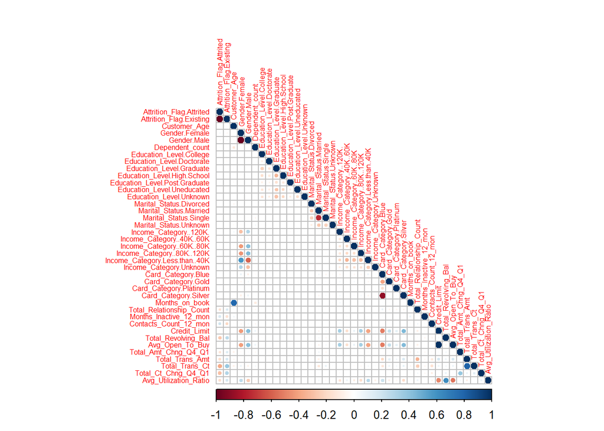

```r
#install.packages(corrplot)
library(corrplot)
corrMatrix<-cor(ChurnDataV2)
corrplot(corrMatrix, tl.cex=0.5, type="lower", insig="blank")
```

Churn Distribution - Pie Chart

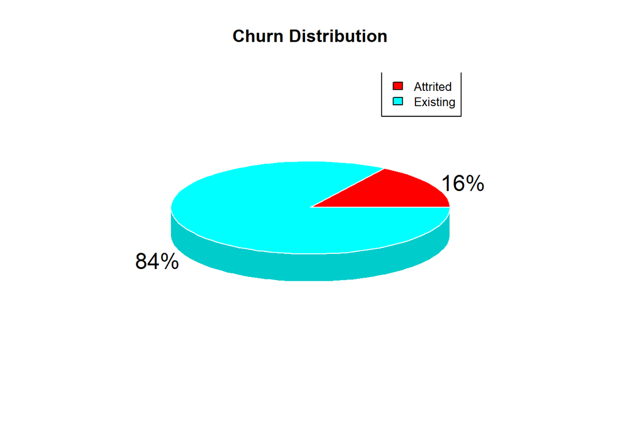

```r
#install.packages("plotrix")
library(plotrix)
attritionTable<-table(ChurnDataV1$Attrition_Flag)
pie3D(attritionTable, main="Churn Distribution", labels = paste0(round(attritionTable/sum(attritionTable)*100, 0), "%"), border="white", col = rainbow(length(attritionTable)))
legend("topright", legend=levels(ChurnDataV1$Attrition_Flag), cex = 0.8, fill = rainbow(length(attritionTable)))
```

Age Distribution - Histogram

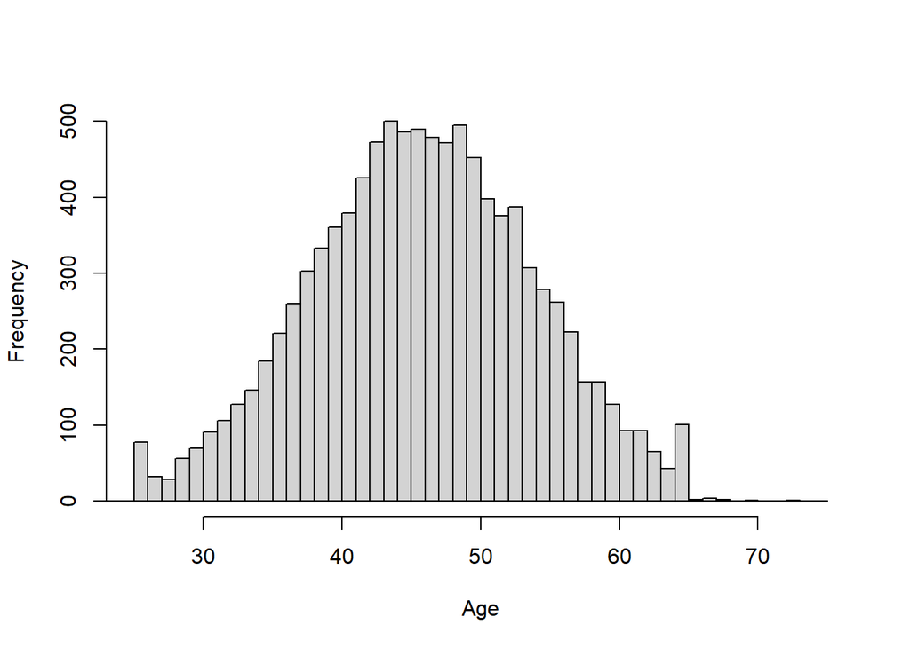

```r
hist(ChurnDataV1$Customer_Age, breaks=c(20:75),
     main="",
     xlab="Age",
     xlim = c(25,75), ylim = c(0,500))
```

Gender Distribution - Pie Chart

```r
#install.packages("lessR")
library(lessR)
```

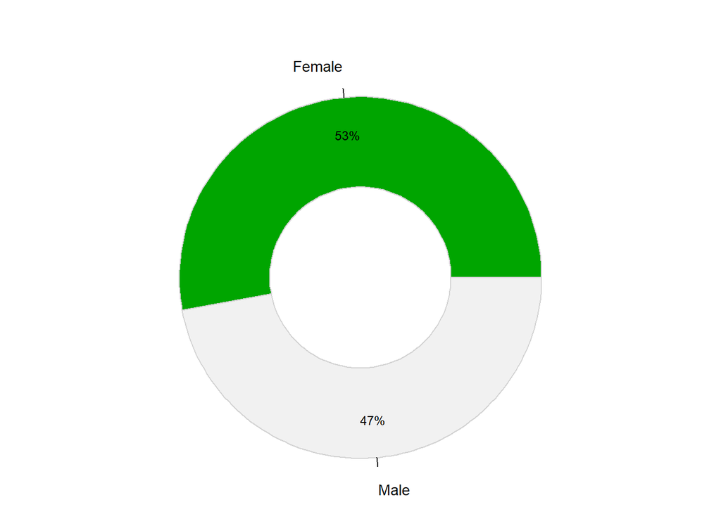

```
## >>> Suggestions
## PieChart(gend, hole=0)  # traditional pie chart
## PieChart(gend, values="%")  # display %'s on the chart
## PieChart(gend)  # bar chart
## Plot(gend)  # bubble plot
## Plot(gend, values="count")  # lollipop plot
##
## --- gend ---
##
##                Female   Male       Total
## Frequencies:     5358   4769       10127
## Proportions:    0.529  0.471       1.000
##
## Chi-squared test of null hypothesis of equal probabilities
##   Chisq = 34.257, df = 1, p-value = 0.000
```

```r
gender <- data.frame(gend = ChurnDataV1$Gender)
PieChart(gend, hole = 0.5, values = "%", values_color = "black", data = gender,
         fill = "terrain", main="")
```

Gender vs Churn Table with %

```r
#install.packages("janitor")
library(janitor)
ChurnDataV1 %>%
  tabyl(Gender, Attrition_Flag) %>%
  adorn_percentages("row") %>%
  adorn_pct_formatting(digits=0)
```

```
##  Gender Attrited Existing
##  Female      17%      83%
##    Male      15%      85%
```

Number of Dependents - Pie Chart

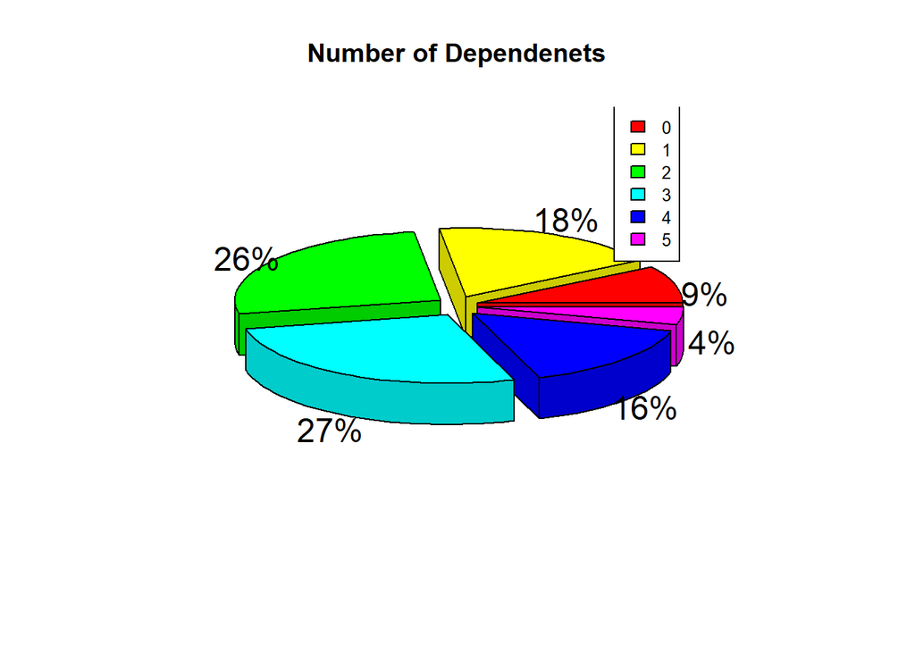

```r
#install.packages("plotrix")
library(plotrix)
dependentTable<-table(ChurnDataV1$Dependent_count)
pie3D(dependentTable, main="Number of Dependenets", labels = paste0(round(dependentTable/sum(dependentTable)*100, 0), "%"), explode=0.1, col = rainbow(length(dependentTable)))
legend("topright", legend = c("0", "1", "2", "3", "4", "5"), cex = 0.8, fill = rainbow(length(dependentTable)))
```

Dependents vs Churn Table with %

```r
#install.packages("janitor")
library(janitor)
ChurnDataV1 %>%
  tabyl(Dependent_count, Attrition_Flag) %>%
  adorn_percentages("row") %>%
  adorn_pct_formatting(digits=0)
```

```
##  Dependent_count Attrited Existing
##                0      15%      85%
##                1      15%      85%
##                2      16%      84%
##                3      18%      82%
##                4      17%      83%
##                5      15%      85%
```

Education Level - Pie Chart

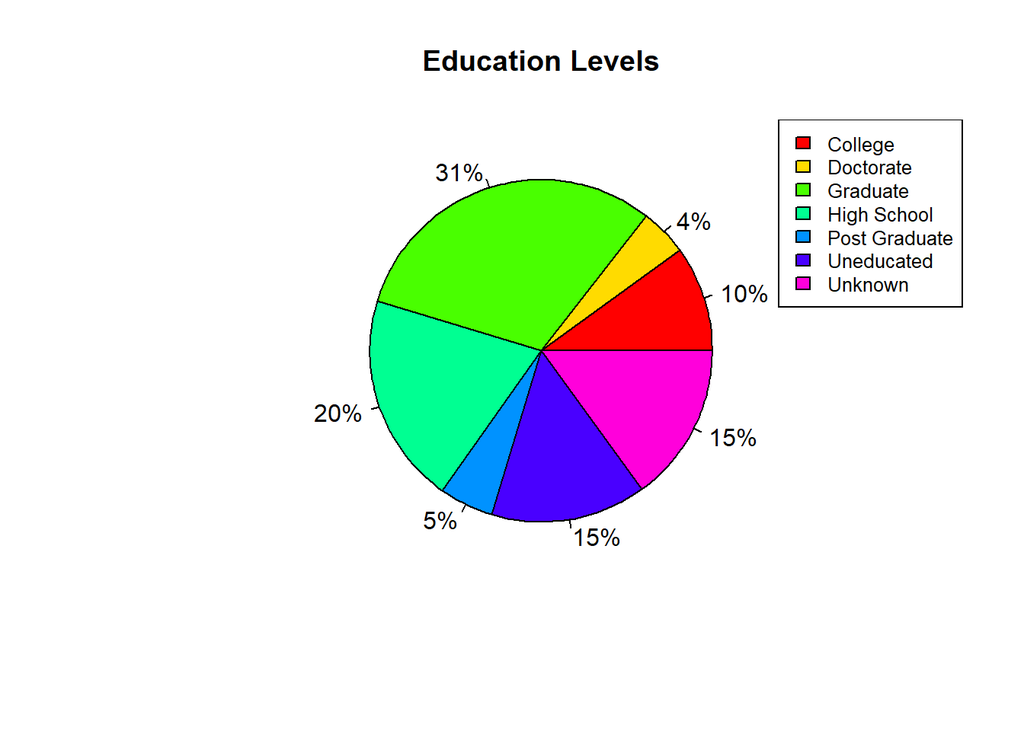

```r
educationTable<-table(ChurnDataV1$Education_Level)
pie(educationTable, main="Education Levels", labels = paste0(round(educationTable/sum(dependentTable)*100, 0), "%"), col = rainbow(length(educationTable)))
legend("topright", legend=levels(ChurnDataV1$Education_Level), cex = 0.8, fill = rainbow(length(educationTable)))
```

Education vs Churn Table with %

```r
#install.packages("janitor")
library(janitor)
ChurnDataV1 %>%
  tabyl(Education_Level, Attrition_Flag) %>%
  adorn_percentages("row") %>%
  adorn_pct_formatting(digits=0)
```

```
##  Education_Level Attrited Existing
##          College      15%      85%
##        Doctorate      21%      79%
##         Graduate      16%      84%
##      High School      15%      85%
##    Post Graduate      18%      82%
##       Uneducated      16%      84%
##          Unknown      17%      83%
```

Marital Status - Pie Chart

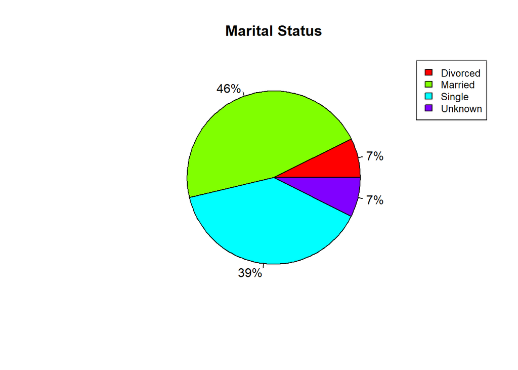

```r
MaritalTable<-table(ChurnDataV1$Marital_Status)
pie(MaritalTable, main="Marital Status", labels = paste0(round(MaritalTable/sum(MaritalTable)*100, 0), "%"), col = rainbow(length(MaritalTable)))
legend("topright", legend=levels(ChurnDataV1$Marital_Status), cex = 0.8, fill = rainbow(length(MaritalTable)))
```

Marital Status vs Churn Table with %

```r
#install.packages("janitor")
library(janitor)
ChurnDataV1 %>%
  tabyl(Marital_Status, Attrition_Flag) %>%
  adorn_percentages("row") %>%
  adorn_pct_formatting(digits=0)
```

```
##  Marital_Status Attrited Existing
##        Divorced      16%      84%
##         Married      15%      85%
##          Single      17%      83%
##         Unknown      17%      83%
```

Income Category - Pie Chart

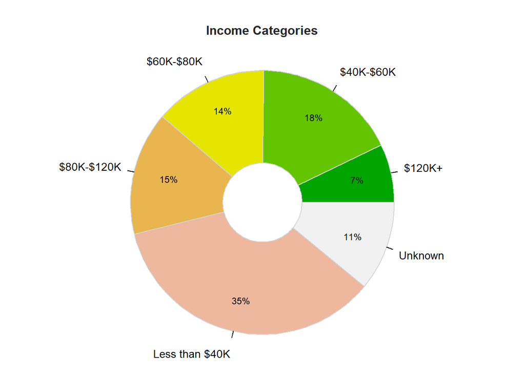

```
## >>> Suggestions
## PieChart(inc, hole=0)  # traditional pie chart
## PieChart(inc, values="%")  # display %'s on the chart
## PieChart(inc)  # bar chart
## Plot(inc)  # bubble plot
## Plot(inc, values="count")  # lollipop plot
##
## --- inc ---
##
##            inc   Count   Prop
## ------------------------------
##         $120K+     727   0.072
##      $40K-$60K    1790   0.177
##      $60K-$80K    1402   0.138
##     $80K-$120K    1535   0.152
## Less than $40K    3561   0.352
##        Unknown    1112   0.110
## ------------------------------
##          Total   10127   1.000
##
## Chi-squared test of null hypothesis of equal probabilities
##   Chisq = 2890.709, df = 5, p-value = 0.000
```

```r
#install.packages("lessR")
library(lessR)
income <- data.frame(inc = ChurnDataV1$Income_Category)
PieChart(inc, hole = 0.3, values = "%", values_color = "black", data = income,
         fill = "terrain", main="Income Categories")
```

Income vs Churn Table with %

```r
#install.packages("janitor")
library(janitor)
ChurnDataV1 %>%
  tabyl(Income_Category, Attrition_Flag) %>%
  adorn_percentages("row") %>%
  adorn_pct_formatting(digits=0)
```

```
##  Income_Category Attrited Existing
##           $120K+      17%      83%
##        $40K-$60K      15%      85%
##        $60K-$80K      13%      87%
##       $80K-$120K      16%      84%
##   Less than $40K      17%      83%
##          Unknown      17%      83%
```

Card Category - Pie Chart

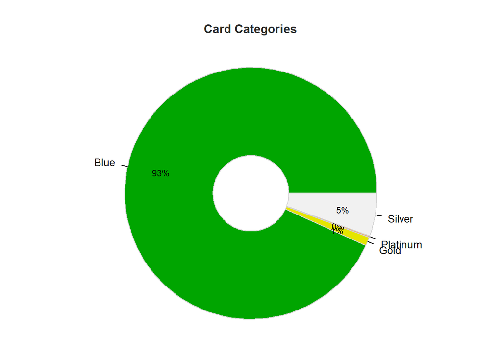

```
## >>> Suggestions
## PieChart(card, hole=0)  # traditional pie chart
## PieChart(card, values="%")  # display %'s on the chart
## PieChart(card)  # bar chart
## Plot(card)  # bubble plot
## Plot(card, values="count")  # lollipop plot
##
## --- card ---
##
##                 Blue   Gold  Platinum  Silver       Total
## Frequencies:    9436    116        20     555       10127
## Proportions:   0.932  0.011     0.002   0.055       1.000
##
## Chi-squared test of null hypothesis of equal probabilities
##   Chisq = 25168.735, df = 3, p-value = 0.000
```

```r
#install.packages("lessR")
library(lessR)
cardCat <- data.frame(card = ChurnDataV1$Card_Category)
PieChart(card, hole = 0.3, values = "%", values_color = "black", data = cardCat,
         fill = "terrain", main="Card Categories")
```

Months on Book - Histogram

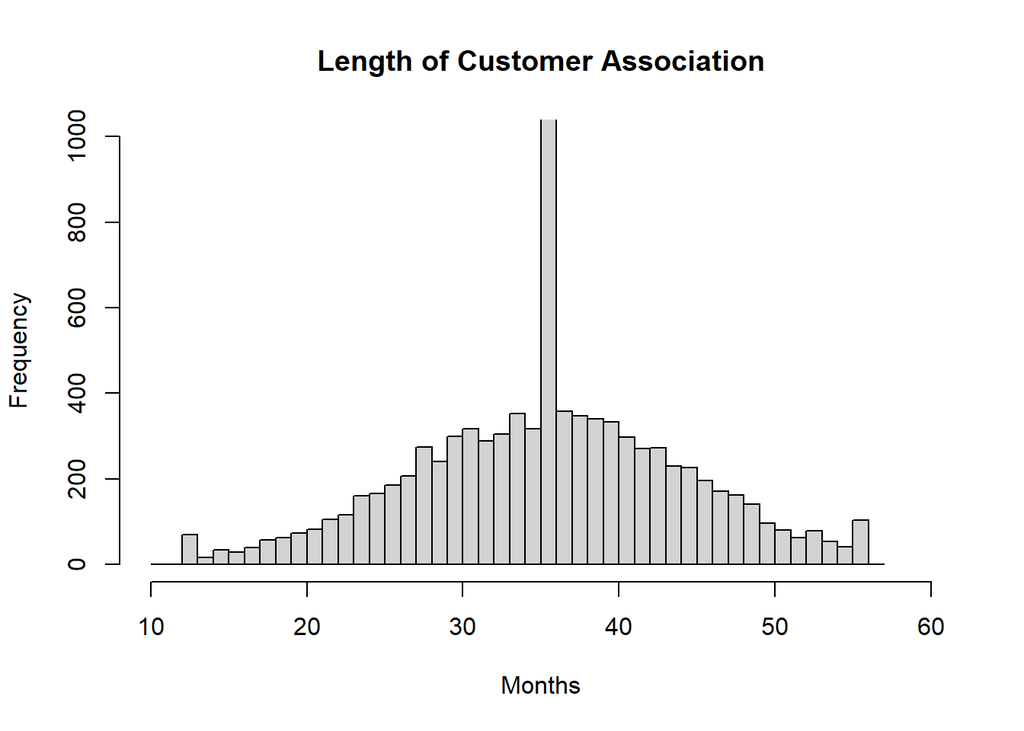

```r
hist(ChurnDataV1$Months_on_book, breaks=c(10:57),
     main="Length of Customer Association",
     xlab="Months",
     xlim = c(10,60), ylim = c(0,1000))
```

Months on Book vs Churn - Density Plot

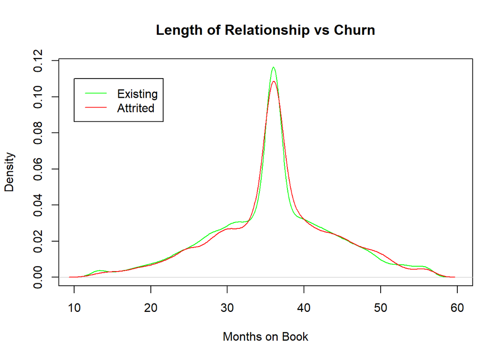

```r
plot(density(ChurnDataV1$Months_on_book[which(ChurnDataV1$Attrition_Flag=="Existing")]),
     xlim=c(10,60), main="Length of Relationship vs Churn",
     xlab="Months on Book",
     col="green", lty=1)
lines(density(ChurnDataV1$Months_on_book[which(ChurnDataV1$Attrition_Flag=="Attrited")]),
      col="red", lty=1)
legend(10,0.11, legend=c("Existing","Attrited"),
       col=c("green", "red"), lty=c(1,1))
```

Total Relationships - Histogram

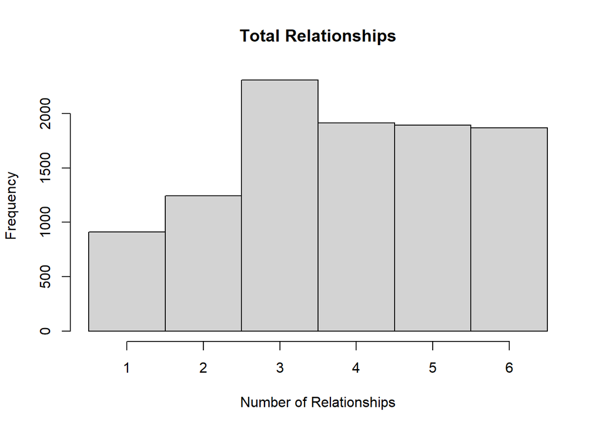

```r
hist(ChurnDataV1$Total_Relationship_Count, breaks=c(0.5:6.5),
     main="Total Relationships",
     xlab="Number of Relationships")
```

Total Relationships vs Churn - Boxplot

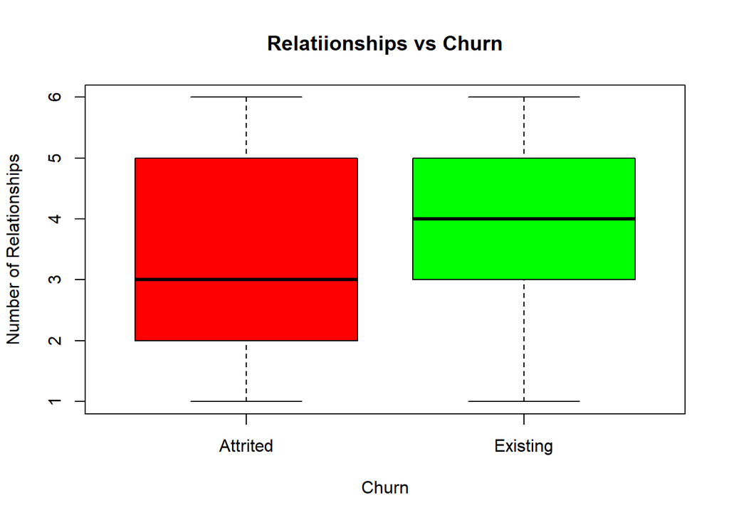

```r
boxplot(ChurnDataV1$Total_Relationship_Count ~ ChurnDataV1$Attrition_Flag,
        main="Relatiionships vs Churn",
        xlab="Churn", ylab="Number of Relationships",
        col=c("red", "green", alpha=0.5),
        outpch=21, outbg="black")
```

Total Relationships vs Churn - Stacked % Bar graph

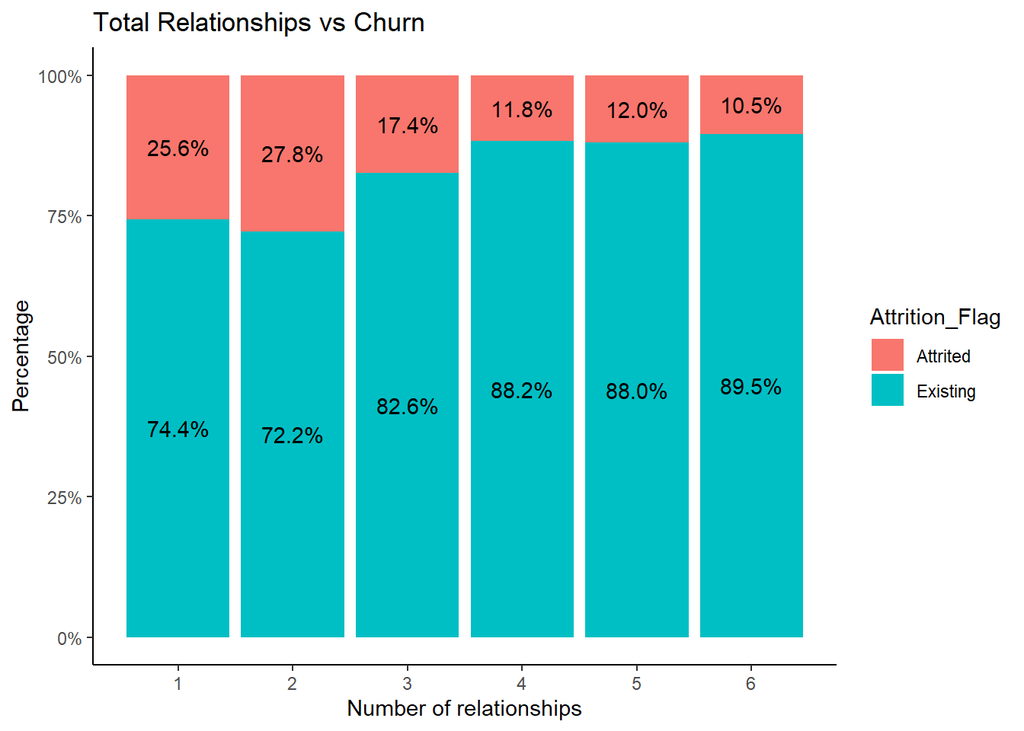

```r
library(ggplot2)
library(dplyr)
#Additional field to get % values in the stacked bar graph
RelationData <- ChurnDataV1%>%
  dplyr::group_by(Total_Relationship_Count, Attrition_Flag)%>%
  dplyr::tally()%>%
  dplyr::mutate(percent=n/sum(n))

ggplot(data = RelationData,aes(x= Total_Relationship_Count, y = n, fill = Attrition_Flag)) +
  geom_bar(stat="identity", position ="fill") +
  scale_x_continuous(breaks=c(1,2,3,4,5,6)) +
  geom_text(aes(label=paste0(sprintf("%1.1f", percent*100),"%")),
                     position=position_fill(vjust=0.5)) +
  scale_y_continuous(labels = scales::percent) +
  labs(title="Total Relationships vs Churn", x="Number of relationships", y="Percentage") +
  theme_bw() + theme(panel.grid.major = element_blank(), panel.grid.minor = element_blank(), panel.border = element_blank(),
    axis.line = element_line(colour = "black"))
```

Months Inactive - Histogram

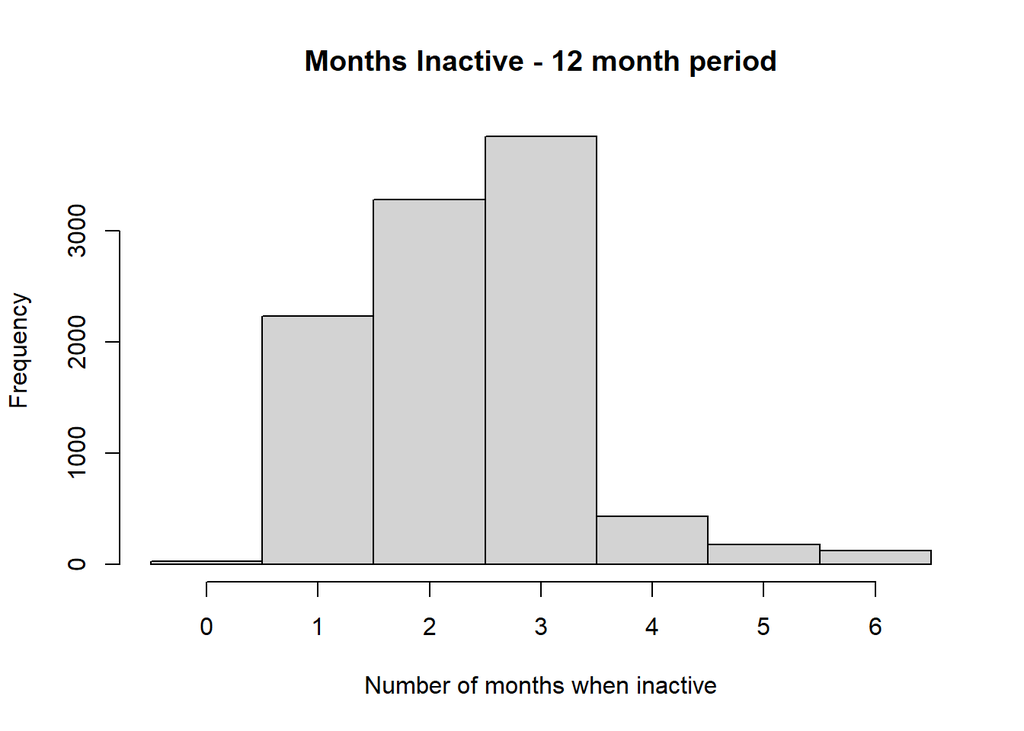

```r
hist(ChurnDataV1$Months_Inactive_12_mon, breaks=c(-0.5:6.5),
     main="Months Inactive - 12 month period",
     xlab="Number of months when inactive")
```

Months Inactive vs Churn - Boxplot

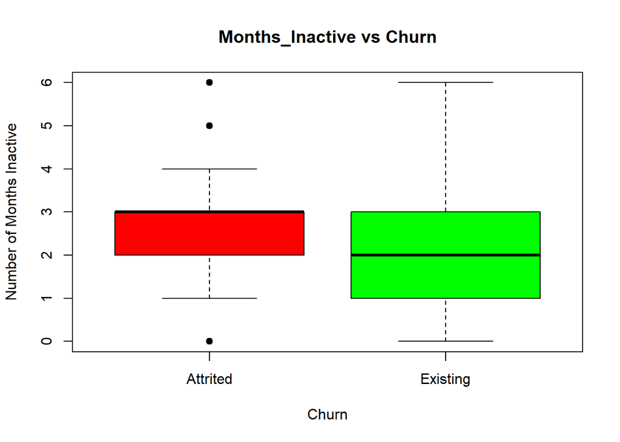

```r
boxplot(ChurnDataV1$Months_Inactive_12_mon ~ ChurnDataV1$Attrition_Flag,
        main="Months_Inactive vs Churn",
        xlab="Churn", ylab="Number of Months Inactive",
        col=c("red", "green"),
        outpch=21, outbg="black")
```

Contacts Count - Histogram

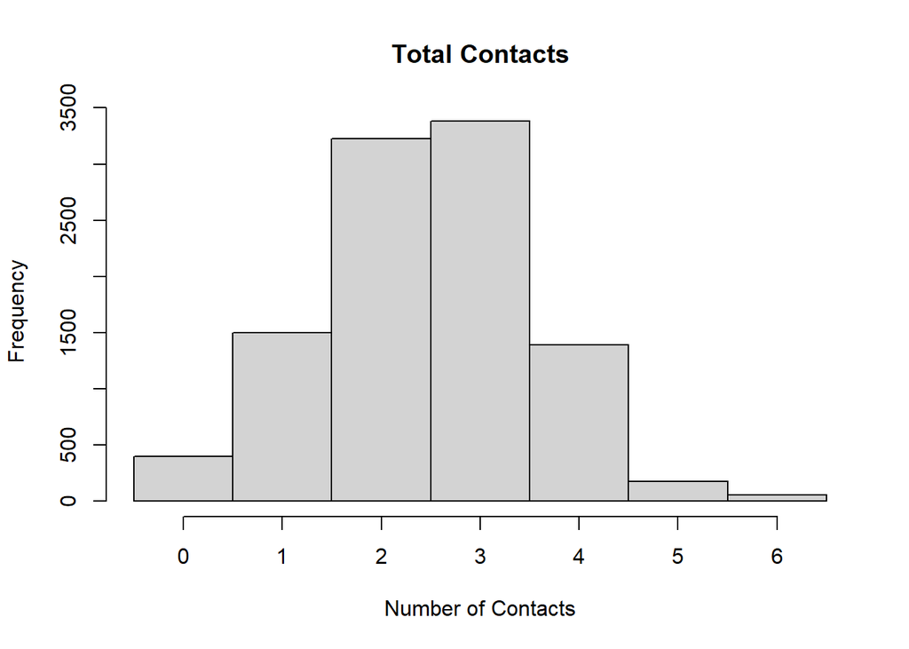

```r
hist(ChurnDataV1$Contacts_Count_12_mon, breaks=c(-0.5:6.5),
     main="Total Contacts",
     xlab="Number of Contacts")
```

Contacts vs Churn - Boxplot

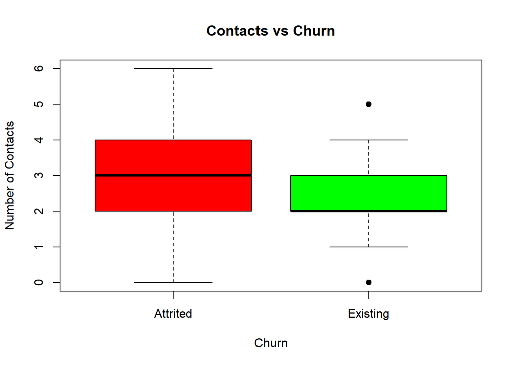

```r
boxplot(ChurnDataV1$Contacts_Count_12_mon ~ ChurnDataV1$Attrition_Flag,
        main="Contacts vs Churn",
        xlab="Churn", ylab="Number of Contacts",
        col=c("red", "green"),
        outpch=21, outbg="black")
```

Contacts vs Churn - Stacked % Bar graph

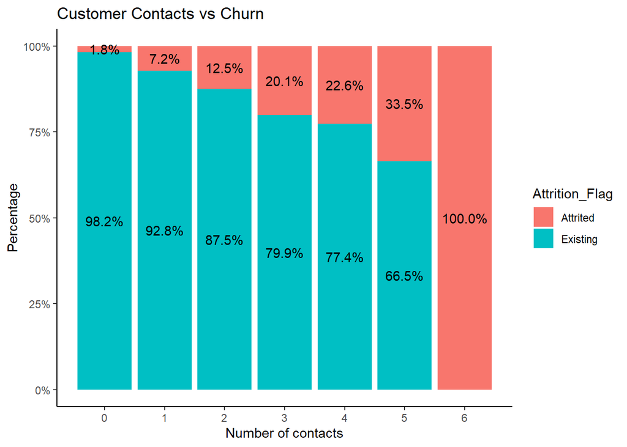

```r
library(ggplot2)
library(dplyr)
#Additional field to get % values in the stacked bar graph
ContactData <- ChurnDataV1%>%
  dplyr::group_by(Contacts_Count_12_mon, Attrition_Flag)%>%
  dplyr::tally()%>%
  dplyr::mutate(percent=n/sum(n))

ggplot(data = ContactData,aes(x= Contacts_Count_12_mon, y = n, fill = Attrition_Flag)) +
  geom_bar(stat="identity", position ="fill") +
  scale_x_continuous(breaks=c(0,1,2,3,4,5,6)) +
  geom_text(aes(label=paste0(sprintf("%1.1f", percent*100),"%")),
                     position=position_fill(vjust=0.5)) +
  scale_y_continuous(labels = scales::percent) +
  labs(title="Customer Contacts vs Churn", x="Number of contacts", y="Percentage") +
  theme_bw() + theme(panel.grid.major = element_blank(), panel.grid.minor = element_blank(), panel.border = element_blank(),
    axis.line = element_line(colour = "black"))
```

Credit Limit - Histogram

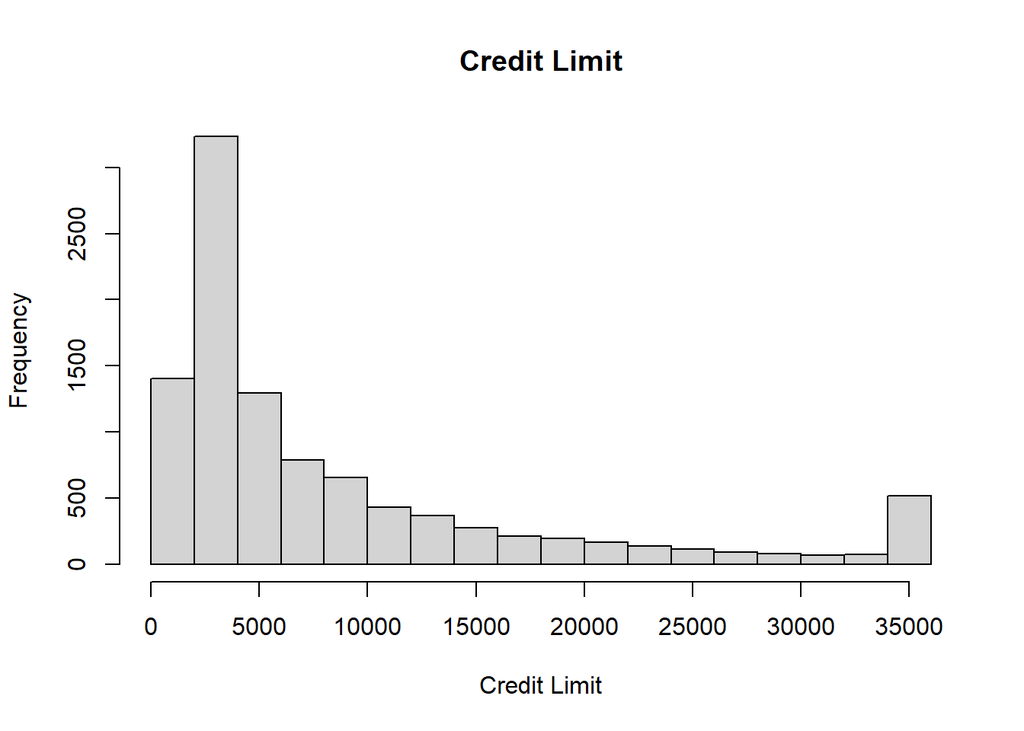

```r
hist(ChurnDataV1$Credit_Limit,
     main="Credit Limit", xlab="Credit Limit")
```

Credit Limit vs Churn - Density Plot

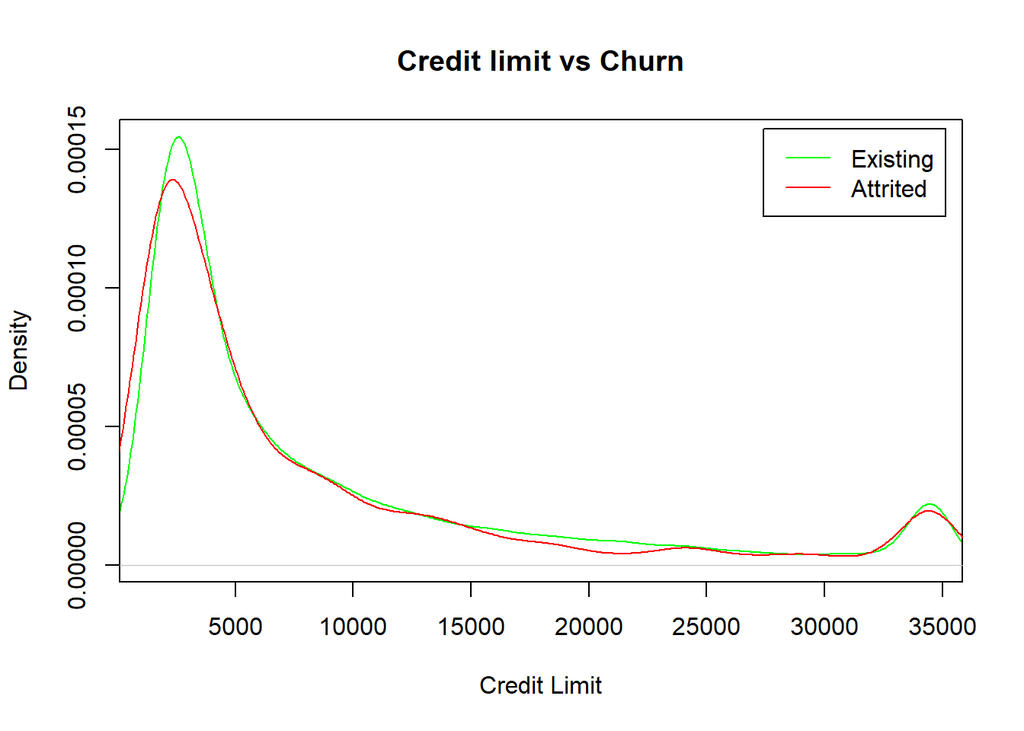

```r
plot(density(ChurnDataV1$Credit_Limit[which(ChurnDataV1$Attrition_Flag=="Existing")]),
     xlim=c(1420,34520), main="Credit limit vs Churn",
     xlab="Credit Limit",
     col="green", lty=1)
lines(density(ChurnDataV1$Credit_Limit[which(ChurnDataV1$Attrition_Flag=="Attrited")]),
      col="red", lty=1)
legend("topright", inset=.02, legend=c("Existing","Attrited"),
       col=c("green", "red"), lty=c(1,1))
```

Total Revolving Balance - Histogram

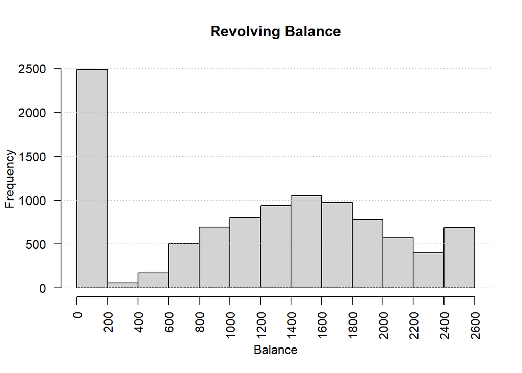

```r
hist(ChurnDataV1$Total_Revolving_Bal,
     main="Revolving Balance", xlab="Balance", las=2, xaxp=c(0,2600,13))
abline(h=seq(0,2500,500), col="gray", lty="dotted")
```

Credit Limit vs Revolving Balance - Density Plot

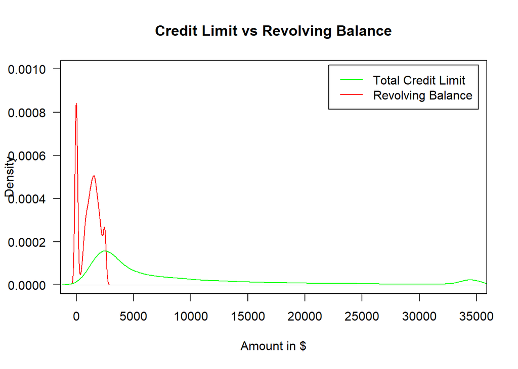

```r
plot(density(ChurnDataV1$Credit_Limit),
     xlim=c(0,34520), ylim=c(0,0.0010), las=1, main="Credit Limit vs Revolving Balance",
     xlab="Amount in $",
     col="green", lty=1)
lines(density(ChurnDataV1$Total_Revolving_Bal),
      col="red", lty=1)
legend("topright", inset=.02, legend=c("Total Credit Limit","Revolving Balance"),
       col=c("green", "red"), lty=c(1,1))
```

Total Transaction Count - Histogram

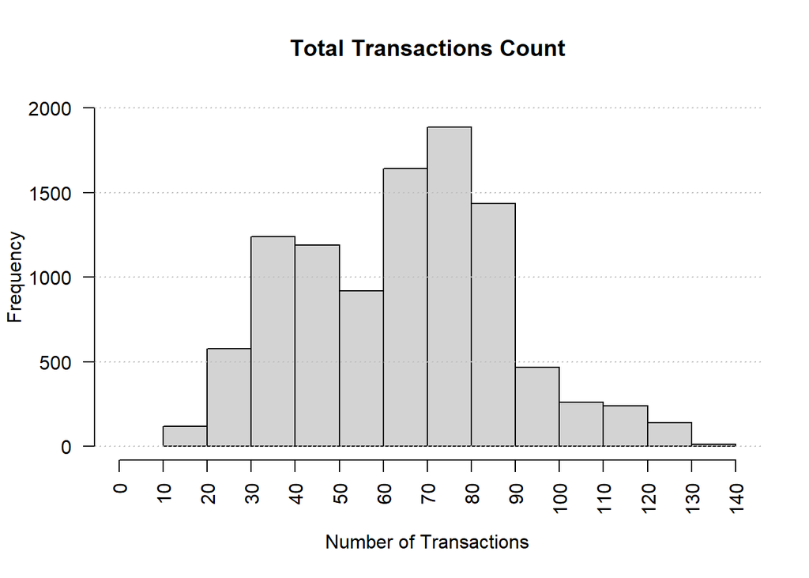

```r
hist(ChurnDataV1$Total_Trans_Ct,
     main="Total Transactions Count", xlab="Number of Transactions",
     xlim=c(0,140), xaxp=c(0,140,14), las=2, ylim=c(0,2000))
abline(h=seq(0,2000,500), col="gray", lty="dotted")
```

Transaction Count vs Churn - Density Plot

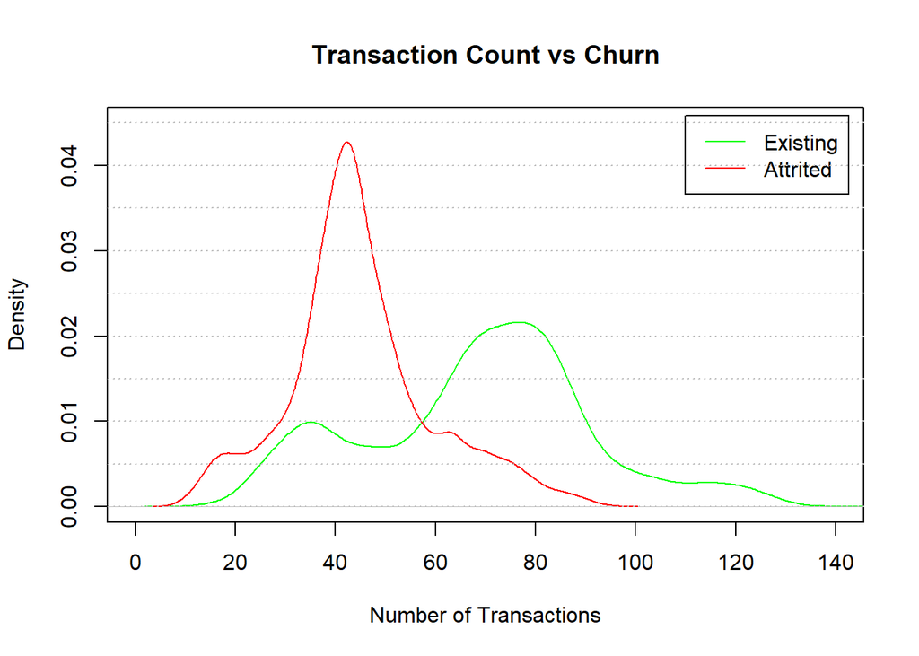

```r
plot(density(ChurnDataV1$Total_Trans_Ct[which(ChurnDataV1$Attrition_Flag=="Existing")]),
     xlim=c(0,140), ylim=c(0,0.045), main="Transaction Count vs Churn",
     xlab="Number of Transactions",
     col="green", lty=1)
lines(density(ChurnDataV1$Total_Trans_Ct[which(ChurnDataV1$Attrition_Flag=="Attrited")]),
      col="red", lty=1)
legend("topright", inset=.02, legend=c("Existing","Attrited"),
       col=c("green", "red"), lty=c(1,1))
abline(h=seq(0,0.045,0.005), col="gray", lty="dotted")
```

Transaction Count vs Churn - Boxplot

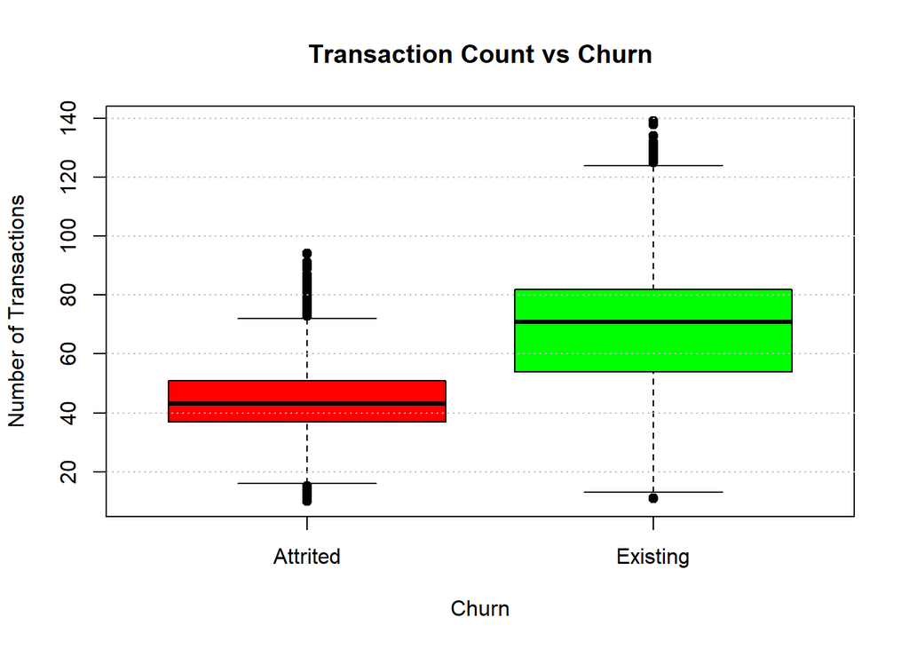

```r
boxplot(ChurnDataV1$Total_Trans_Ct ~ ChurnDataV1$Attrition_Flag,
        main="Transaction Count vs Churn",
        xlab="Churn", ylab="Number of Transactions",
        col=c("red", "green"),
        outpch=21, outbg="black")
abline(h=seq(0,140,20), col="gray", lty="dotted")
```

Subset with only Transaction Count and Attrition Flag

```r
TxnDF<-subset(ChurnDataV1, select = c(Attrition_Flag, Total_Trans_Ct))
str(TxnDF)
```

```
## 'data.frame':    10127 obs. of  2 variables:
##  $ Attrition_Flag: Factor w/ 2 levels "Attrited","Existing": 2 2 2 2 2 2 2 2 2 2 ...
##  $ Total_Trans_Ct: int  42 33 20 20 28 24 31 36 24 32 ...
```

Churn Distribution with Transaction Count cut-off at 48 - Stacked % Bar graph

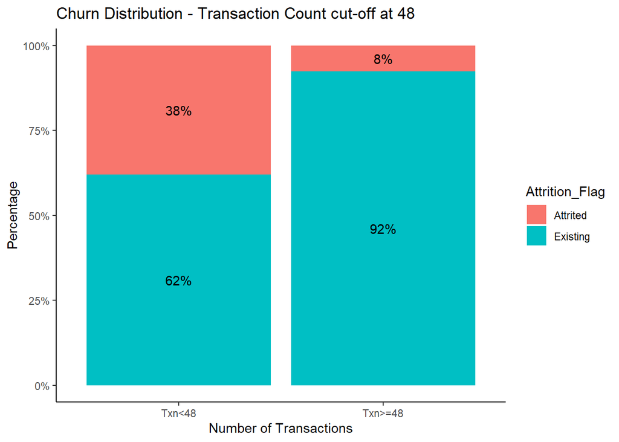

```r
library(ggplot2)
library(dplyr)
#New Column for Txn count indicator
TxnDF$TxnCnt1<-ifelse(TxnDF$Total_Trans_Ct>=48, "Txn>=48", "Txn<48")
#Additional field to get % values in the stacked bar graph
TempTxnData1 <- TxnDF%>%
  dplyr::group_by(TxnCnt1, Attrition_Flag)%>%
  dplyr::tally()%>%
  dplyr::mutate(percent=n/sum(n))

ggplot(data = TempTxnData1,aes(x=TxnCnt1, y = n, fill = Attrition_Flag)) +
  geom_bar(stat="identity", position ="fill") +
  scale_x_discrete(breaks=c("Txn>=48", "Txn<48")) +
  geom_text(aes(label=paste0(sprintf("%1.0f", percent*100),"%")),
                     position=position_fill(vjust=0.5)) +
  scale_y_continuous(labels = scales::percent) +
  labs(title="Churn Distribution - Transaction Count cut-off at 48", x="Number of Transactions", y="Percentage") +
  theme_bw() + theme(panel.grid.major = element_blank(), panel.grid.minor = element_blank(), panel.border = element_blank(),
    axis.line = element_line(colour = "black"))
```

Transaction Count Change vs Churn - Histogram with density plot

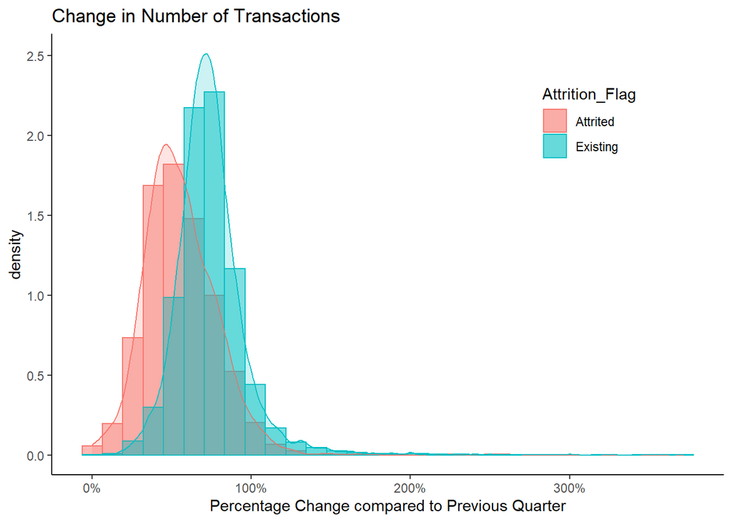

```r
library(ggplot2)
library(scales)
ggplot(ChurnDataV1, aes(x=Total_Ct_Chng_Q4_Q1, color=Attrition_Flag, fill=Attrition_Flag)) +
  geom_histogram(aes(y=..density..), position = "identity", alpha=0.5)+
  labs(title="Change in Number of Transactions", x="Percentage Change compared to Previous Quarter") +
  scale_x_continuous(labels = percent) +
  geom_density(alpha=.2) +
  theme_classic() +
  theme(legend.position = c(0.8,0.8))
```

Total Transaction Amount - Histogram

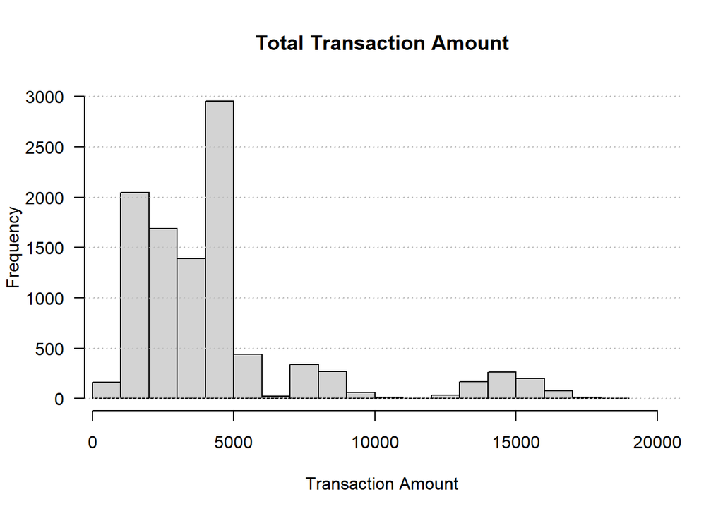

```r
hist(ChurnDataV1$Total_Trans_Amt,
     main="Total Transaction Amount", xlab="Transaction Amount",
     xlim=c(500,20000), las=1, ylim=c(0,3000))
abline(h=seq(0,3000,500), col="gray", lty="dotted")
```

Transaction Amount vs Churn - Density Plot

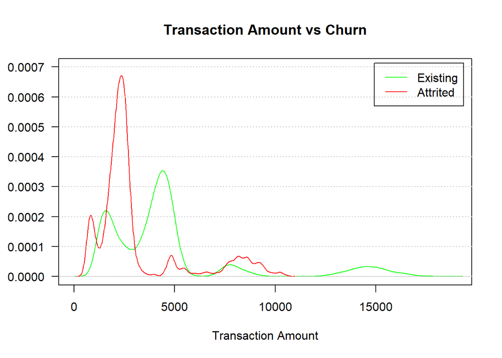

```r
plot(density(ChurnDataV1$Total_Trans_Amt[which(ChurnDataV1$Attrition_Flag=="Existing")]),
     xlim=c(0,19000), ylim = c(0,0.0007), main="Transaction Amount vs Churn",
     xlab="Transaction Amount", ylab="",
     las=1,
     col="green", lty=1)
lines(density(ChurnDataV1$Total_Trans_Amt[which(ChurnDataV1$Attrition_Flag=="Attrited")]),
      col="red", lty=1)
legend("topright", inset=.02, legend=c("Existing","Attrited"),
       col=c("green", "red"), lty=c(1,1))
abline(h=seq(0,0.0007,0.0001), col="gray", lty="dotted")
```

Utilization ratio - Histogram

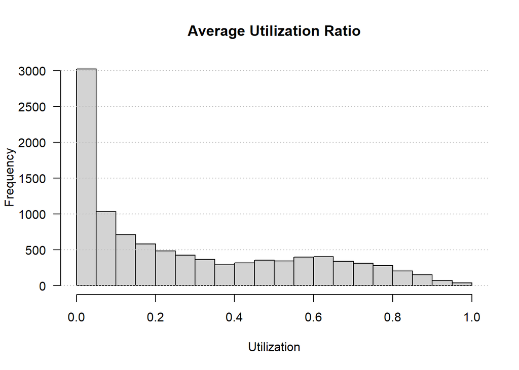

```r
hist(ChurnDataV1$Avg_Utilization_Ratio,
     main="Average Utilization Ratio", xlab="Utilization", las=1)
abline(h=seq(0,3000,500), col="gray", lty="dotted")
```

Utlization Ratio vs Churn - Boxplot

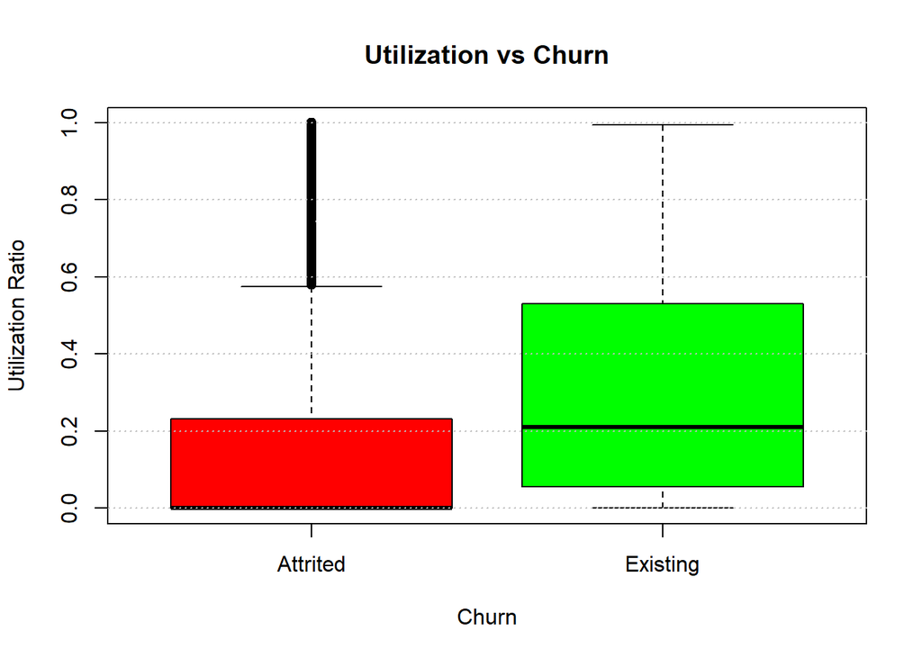

```r
boxplot(ChurnDataV1$Avg_Utilization_Ratio ~ ChurnDataV1$Attrition_Flag,
        main="Utilization vs Churn",
        xlab="Churn", ylab="Utilization Ratio",
        col=c("red", "green"),
        outpch=21, outbg="black")
abline(h=seq(0,1,0.2), col="gray", lty="dotted")
```

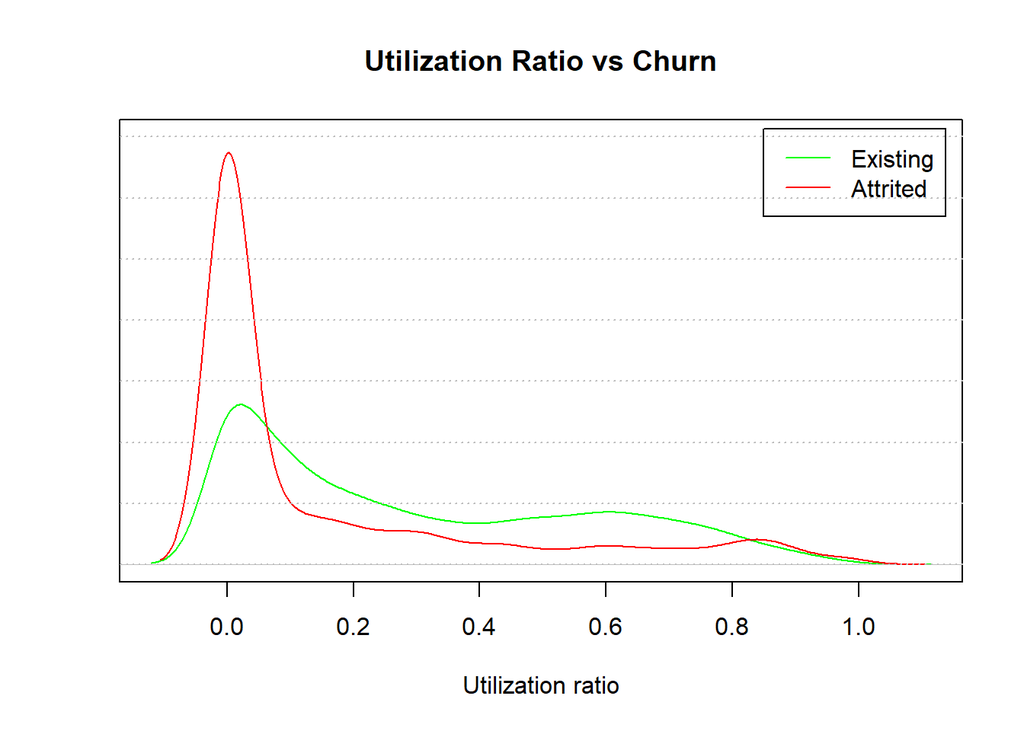

```r
plot(density(ChurnDataV1$Avg_Utilization_Ratio[which(ChurnDataV1$Attrition_Flag=="Existing")]),
     main="Utilization Ratio vs Churn", xlab="Utilization ratio",
     ylim=c(0,7), ylab = "", yaxt="n",
     col="green", lty=1)
lines(density(ChurnDataV1$Avg_Utilization_Ratio[which(ChurnDataV1$Attrition_Flag=="Attrited")]),
      col="red", lty=1)
legend("topright", inset=.02, legend=c("Existing","Attrited"),
       col=c("green", "red"), lty=c(1,1))
abline(h=seq(0,7,1), col="gray", lty="dotted")
```

Churn Distribution when Utilization Ratio = 0

```r
UtilizationTable<-table(ChurnDataV1$Attrition_Flag[which(ChurnDataV1$Avg_Utilization_Ratio==0)])
UtilizationTable
```

```
##
## Attrited Existing
##      893     1577
```

Churn Distribution when Utilization Ratio = 0 - Pie Chart

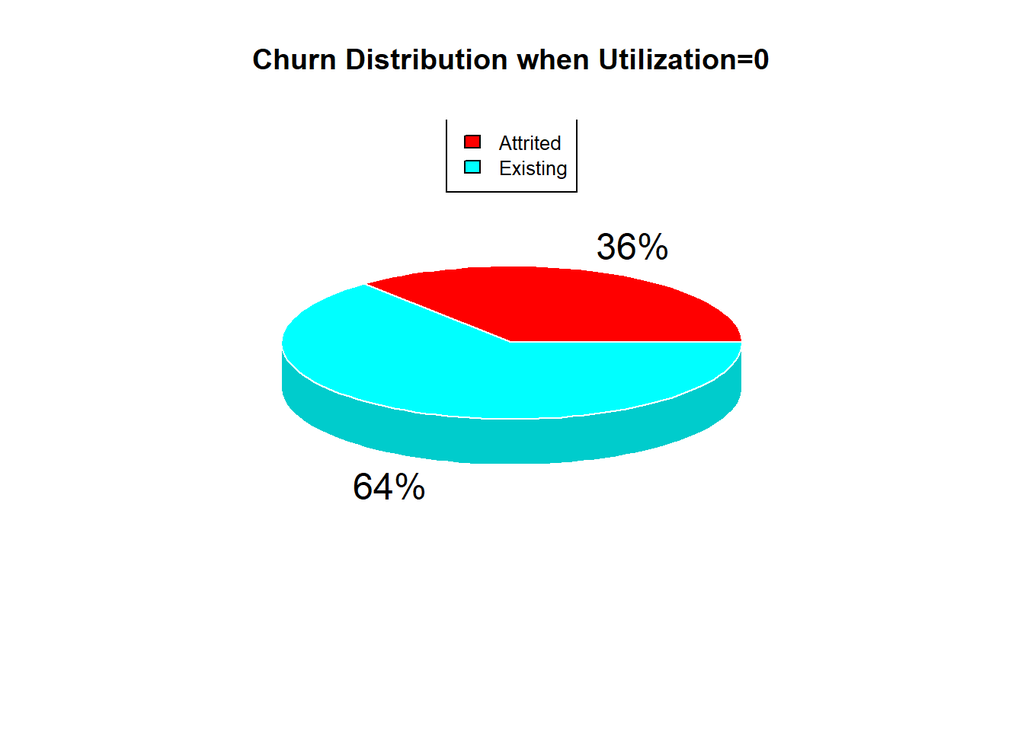

```r
library(plotrix)
pie3D(UtilizationTable, main="Churn Distribution when Utilization=0", labels = paste0(round(UtilizationTable/sum(UtilizationTable)*100, 0), "%"), border="white", col = rainbow(length(UtilizationTable)))
legend("top", legend=levels(ChurnDataV1$Attrition_Flag), cex = 0.8, fill = rainbow(length(UtilizationTable)))
```